# EPL Simulation

Jack Letcher, Treva Winlock, Andrew Brill

March 12, 2018

# English Premier League 1998-2018

## Source: http://www.football-data.co.uk/englandm.php

The Poisson distribution applies when: (1) the event is something that can be counted in whole numbers; (2) occurrences are independent, so that one occurrence neither diminishes nor increases the chance of another; (3) the average frequency of occurrence for the time period in question is known; and (4) it is possible to count how many events have occurred, such as the number of times a team wins or loses during a given season. The Poisson Distribution gives the expected frequency profile for events.

## Temporary Home/Away Tables

```r
# Read in local .csv file
EPL <- read.csv("EPL.csv")

# Format "Date" vector
EPL$Date <- as.Date(dmy(EPL$Date))
EPL$Date <- as.Date(EPL$Date, "%Y/%m/%d")

# Create Match and Team variables
match_table <- paste(EPL$HomeTeam, EPL$AwayTeam, sep = " - ")
team_table <- unique(c(EPL$HomeTeam, EPL$AwayTeam)) %>% sort

# Create home table (Games Played, Pts., Goals Scored, Goals Conceded)
home_table <- EPL %>%
          group_by(HomeTeam) %>%
          summarise(P = length(FTR),
                    Pts = sum((FTHG > FTAG) * 3 + (FTHG == FTAG) * 1),
                    GS = sum(FTHG),
                    GC = sum(FTAG)) %>%
          ungroup()
# Used for a lookup table
home_table <- cbind(home_table, Team_Num = 1:47)

# Create away table (Games Played, Pts., Goals Scored, Goals Conceded)
away_table <- EPL %>%
          group_by(AwayTeam) %>%
          summarise(P = length(FTR),
                    Pts = sum((FTHG < FTAG) * 3 + (FTHG == FTAG) * 1),
                    GS = sum(FTAG),
                    GC = sum(FTHG)) %>%
          ungroup()

# Used for a lookup table
away_table <- cbind(away_table, Team_Num = 1:47)

# Create consolidated table with Total Goals Scored/Conceded
EPL.team.stats <- data.frame(Team = team_table,
                            Points = home_table$Pts + away_table$Pts,
                            GD = (home_table$GS + away_table$GS) - (home_table$GC + away_table$GC),
                            TGS = (home_table$GS + away_table$GS)/(home_table$P + away_table$P),
                            TGC = (home_table$GC + away_table$GC)/(home_table$P + away_table$P), stringsAsFactors = FALSE)
```

### Visualizations

#### Home and Away Team Plot Charts (Games Played, Points, Goals Scored, Goals Conceded)

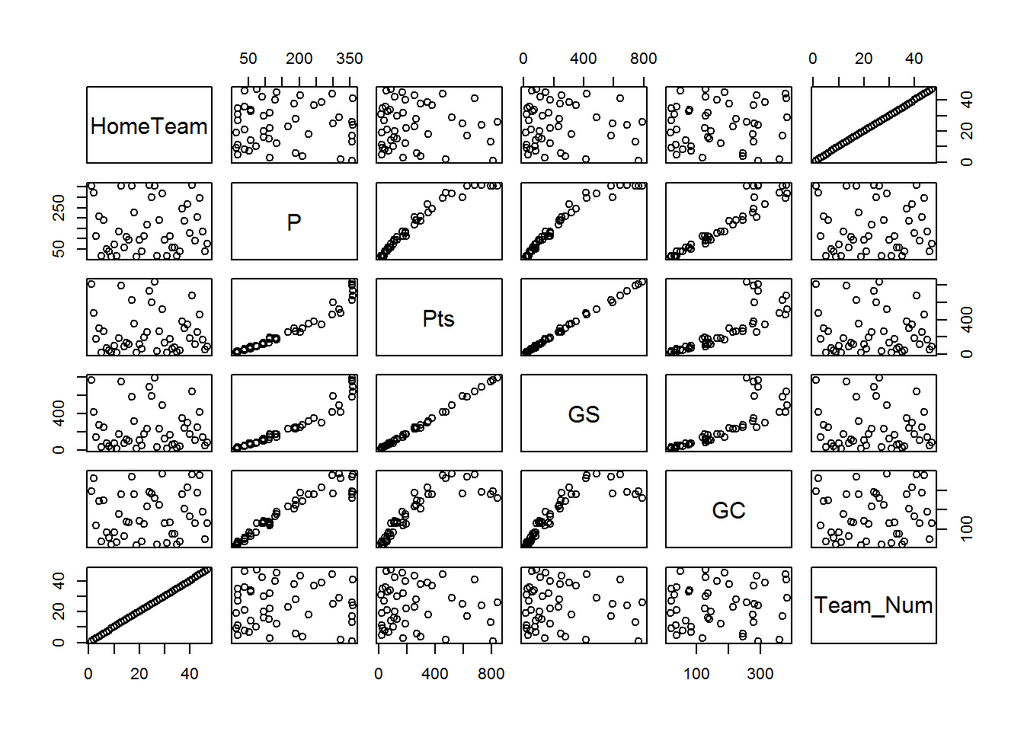

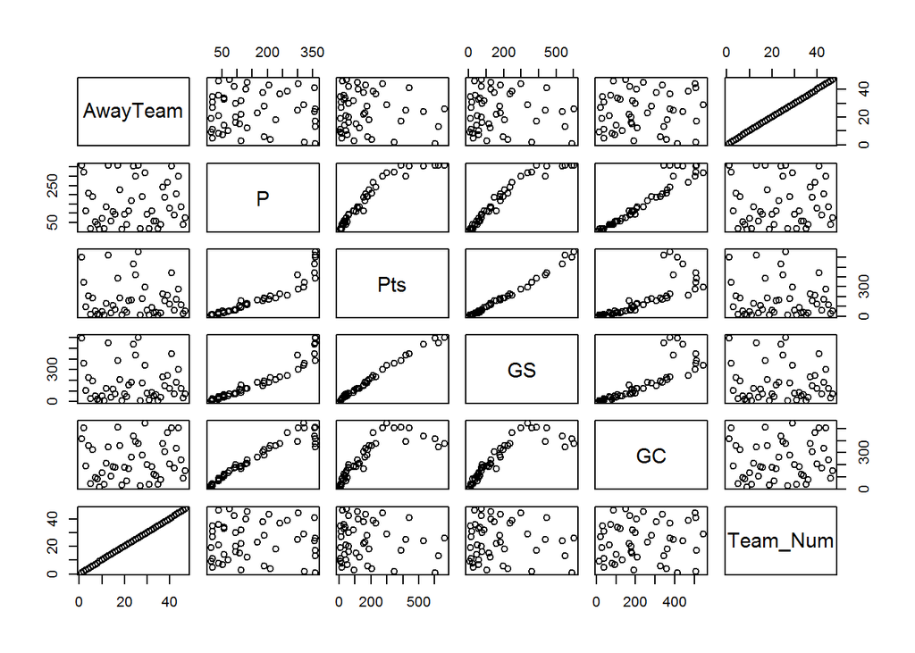

## Matches To Be Played

```r
# Create new EPL table that normalizes Goals Scored and Goals Conceded
# Create Expected Home Goals and Expected Away Goals
EPL.new <- expand.grid(HomeTeam = team_table, AwayTeam = team_table, stringsAsFactors = FALSE) %>%
            filter(HomeTeam != AwayTeam) %>%
            mutate(Match = paste(HomeTeam, AwayTeam, sep = " - ")) %>%
            filter(!(Match %in% match_table)) %>%
            select(-Match) %>%
            mutate(HG = mean(EPL$FTHG),
                   AG = mean(EPL$FTAG),
                   TG = (mean(EPL$FTHG) + mean(EPL$FTAG))/2) %>%
            right_join(subset(EPL.team.stats, select = -c(Points, GD)),  by = c("HomeTeam" = "Team")) %>%
            right_join(subset(EPL.team.stats, select = -c(Points, GD)), by = c("AwayTeam" = "Team")) %>%
            setNames(c("HomeTeam", "AwayTeam", "HG", "AG", "TG",
                       "GSBH", "GCBH", "GSBA", "GCBA")) %>%
            mutate(ExpHG = (GSBH / TG) * (GCBA / TG) * (HG / TG) * TG,
                   ExpAG = (GSBA / TG) * (GCBH / TG) * (AG / TG) * TG) %>%
            ungroup()
```

## Season Simulation

```r
# Number of games simulated
iSimulation <- 500
n <- length(team_table)

# Create new shell for simulation data
EPL.all <- data.frame(Team = rep(team_table, iSimulation),
                     SimNo = rep(1:iSimulation, each = n),
                     Pts = rep(NA, n * iSimulation),
                     GD = rep(NA, n * iSimulation),
                     Rank = rep(NA, n * iSimulation))

# Progress Bar for simulation
win_bar <- winProgressBar(title = "Churning Through Your Simulation",
                     label = "Simulating ... 0% done",
                     min = 0,
                     max = iSimulation,
                     initial = 0)

# For loop that simulates through preset number of loops
for (i in 1:iSimulation){

# Random Generation for Poisson Distribution -- rpois
# Lambda representing vector of non-negative means
  temp_table <- EPL.new %>%
              mutate(x1 = rpois(nrow(EPL.new), lambda = EPL.new$ExpHG),
                     x2 = rpois(nrow(EPL.new), lambda = EPL.new$ExpAG),
                     HPts = 3 * (x1 > x2) + 1 * (x1 == x2),
                     APts = 3 * (x1 < x2) + 1 * (x1 == x2))
# Results table
  results <- EPL.team.stats %>% select(Points, GD) +
         temp_table %>% group_by(HomeTeam) %>% summarise(Pts = sum(HPts),
                                                  GD = sum(x1) - sum(x2)) %>% select(Pts, GD) +
         temp_table %>% group_by(AwayTeam) %>% summarise(Pts = sum(APts),
                                                  GD = sum(x2) - sum(x1)) %>% select(Pts, GD)

  EPL.all[(n*(i-1) + 1):(n*i), c("Pts", "GD")] <- results

  results$PGD <- results$Points + (results$GD - min(results$GD) + 1) / max((results$GD - min(results$GD) + 1) + 1)
  EPL.all[(n*(i-1) + 1):(n*i), c("Rank")] <- rank(-results$PGD, ties.method = "random")

# Progress Bar for simulation results
  info <- sprintf("Simulating ... %d%% complete", round((i/iSimulation)*100))
  setWinProgressBar(win_bar, i, label = info)
}
close(win_bar)
```

## Winner

```r
# Output for Position, also provides probability
EPL.all.new %>% filter(Rank == 1) %>% select(Team) %>% table/iSimulation
```

```
## .
## Man United
##          1
```

## Arsenal Projected Finish

```r
# Output for Team, also provides probability
EPL.all.new %>% filter(Team == "Arsenal") %>% select(Rank) %>% table/iSimulation
```

```
## .
##     2     3
## 0.298 0.702
```

## Arsenal Point Distribution

```r
# Output for Point Distribution, also provides probability
EPL.all.new %>% filter(Team == "Arsenal") %>% select(Pts) %>% table/iSimulation
```

```
## .
##  1573  1577  1579  1580  1583  1585  1587  1588  1589  1590  1591  1592
## 0.002 0.002 0.004 0.006 0.002 0.002 0.002 0.002 0.006 0.002 0.010 0.014
##  1593  1594  1595  1596  1597  1598  1599  1600  1601  1602  1603  1604
## 0.008 0.018 0.010 0.022 0.018 0.022 0.032 0.022 0.022 0.024 0.026 0.046
##  1605  1606  1607  1608  1609  1610  1611  1612  1613  1614  1615  1616
## 0.036 0.056 0.036 0.032 0.038 0.026 0.038 0.034 0.030 0.026 0.024 0.022
##  1617  1618  1619  1620  1621  1622  1623  1624  1625  1626  1627  1628
## 0.032 0.040 0.026 0.018 0.020 0.018 0.016 0.014 0.018 0.012 0.006 0.010
##  1629  1630  1631  1632  1633  1635  1638  1639  1641  1642
## 0.018 0.002 0.004 0.008 0.004 0.002 0.004 0.002 0.002 0.002
```

## Table of Probabilities per Position (Top 9)

```r
# Full table results by Team and probabilties of finish place
full_team_table <- table(EPL.all.new$Team, EPL.all.new$Rank)/iSimulation
full_team_table <- full_team_table[,1:9]
full_team_table
```

```
##
##                        1     2     3     4     5     6     7     8     9
##   Arsenal          0.000 0.298 0.702 0.000 0.000 0.000 0.000 0.000 0.000
##   Aston Villa      0.000 0.000 0.000 0.000 0.000 0.000 0.000 0.616 0.384
##   Birmingham       0.000 0.000 0.000 0.000 0.000 0.000 0.000 0.000 0.000
##   Blackburn        0.000 0.000 0.000 0.000 0.000 0.000 0.000 0.000 0.000
##   Blackpool        0.000 0.000 0.000 0.000 0.000 0.000 0.000 0.000 0.000
##   Bolton           0.000 0.000 0.000 0.000 0.000 0.000 0.000 0.000 0.000
##   Bournemouth      0.000 0.000 0.000 0.000 0.000 0.000 0.000 0.000 0.000
##   Bradford         0.000 0.000 0.000 0.000 0.000 0.000 0.000 0.000 0.000
##   Brighton         0.000 0.000 0.000 0.000 0.000 0.000 0.000 0.000 0.000
##   Burnley          0.000 0.000 0.000 0.000 0.000 0.000 0.000 0.000 0.000
##   Cardiff          0.000 0.000 0.000 0.000 0.000 0.000 0.000 0.000 0.000
##   Charlton         0.000 0.000 0.000 0.000 0.000 0.000 0.000 0.000 0.000
##   Chelsea          0.000 0.702 0.298 0.000 0.000 0.000 0.000 0.000 0.000
##   Coventry         0.000 0.000 0.000 0.000 0.000 0.000 0.000 0.000 0.000
##   Crystal Palace   0.000 0.000 0.000 0.000 0.000 0.000 0.000 0.000 0.000
##   Derby            0.000 0.000 0.000 0.000 0.000 0.000 0.000 0.000 0.000
##   Everton          0.000 0.000 0.000 0.000 0.000 0.040 0.960 0.000 0.000
##   Fulham           0.000 0.000 0.000 0.000 0.000 0.000 0.000 0.000 0.000
##   Huddersfield     0.000 0.000 0.000 0.000 0.000 0.000 0.000 0.000 0.000
##   Hull             0.000 0.000 0.000 0.000 0.000 0.000 0.000 0.000 0.000
##   Ipswich          0.000 0.000 0.000 0.000 0.000 0.000 0.000 0.000 0.000
##   Leeds            0.000 0.000 0.000 0.000 0.000 0.000 0.000 0.000 0.000
##   Leicester        0.000 0.000 0.000 0.000 0.000 0.000 0.000 0.000 0.000
##   Liverpool        0.000 0.000 0.000 1.000 0.000 0.000 0.000 0.000 0.000
##   Man City         0.000 0.000 0.000 0.000 0.000 0.960 0.040 0.000 0.000
##   Man United       1.000 0.000 0.000 0.000 0.000 0.000 0.000 0.000 0.000
##   Middlesboro      0.000 0.000 0.000 0.000 0.000 0.000 0.000 0.000 0.000
##   Middlesbrough    0.000 0.000 0.000 0.000 0.000 0.000 0.000 0.000 0.000
##   Newcastle        0.000 0.000 0.000 0.000 0.000 0.000 0.000 0.384 0.616
##   Norwich          0.000 0.000 0.000 0.000 0.000 0.000 0.000 0.000 0.000
##   Nott'm Forest    0.000 0.000 0.000 0.000 0.000 0.000 0.000 0.000 0.000
##   Portsmouth       0.000 0.000 0.000 0.000 0.000 0.000 0.000 0.000 0.000
##   QPR              0.000 0.000 0.000 0.000 0.000 0.000 0.000 0.000 0.000
##   Reading          0.000 0.000 0.000 0.000 0.000 0.000 0.000 0.000 0.000
##   Sheffield United 0.000 0.000 0.000 0.000 0.000 0.000 0.000 0.000 0.000
##   Sheffield Weds   0.000 0.000 0.000 0.000 0.000 0.000 0.000 0.000 0.000
##   Southampton      0.000 0.000 0.000 0.000 0.000 0.000 0.000 0.000 0.000
##   Stoke            0.000 0.000 0.000 0.000 0.000 0.000 0.000 0.000 0.000
##   Sunderland       0.000 0.000 0.000 0.000 0.000 0.000 0.000 0.000 0.000
##   Swansea          0.000 0.000 0.000 0.000 0.000 0.000 0.000 0.000 0.000
##   Tottenham        0.000 0.000 0.000 0.000 1.000 0.000 0.000 0.000 0.000
##   Watford          0.000 0.000 0.000 0.000 0.000 0.000 0.000 0.000 0.000
##   West Brom        0.000 0.000 0.000 0.000 0.000 0.000 0.000 0.000 0.000
##   West Ham         0.000 0.000 0.000 0.000 0.000 0.000 0.000 0.000 0.000
##   Wigan            0.000 0.000 0.000 0.000 0.000 0.000 0.000 0.000 0.000
##   Wimbledon        0.000 0.000 0.000 0.000 0.000 0.000 0.000 0.000 0.000
##   Wolves           0.000 0.000 0.000 0.000 0.000 0.000 0.000 0.000 0.000
```

### Points

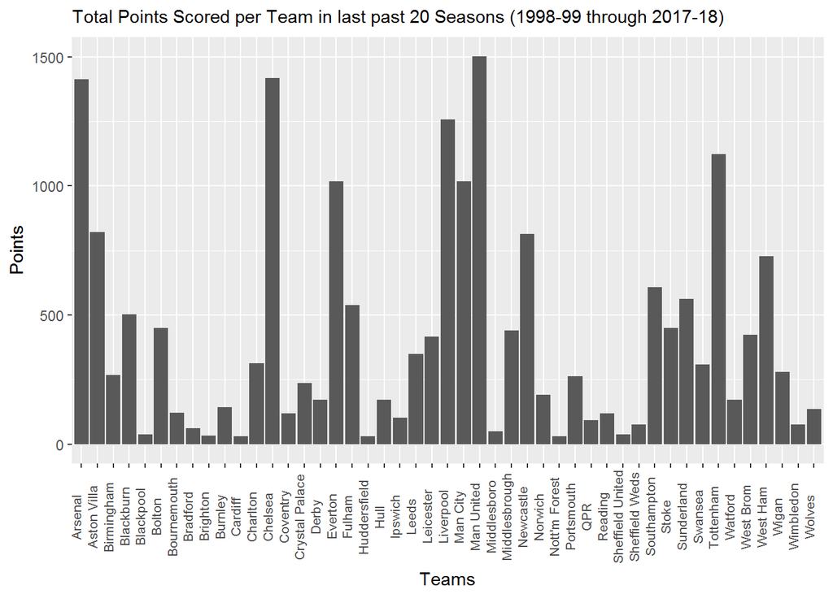

### Goal Differential

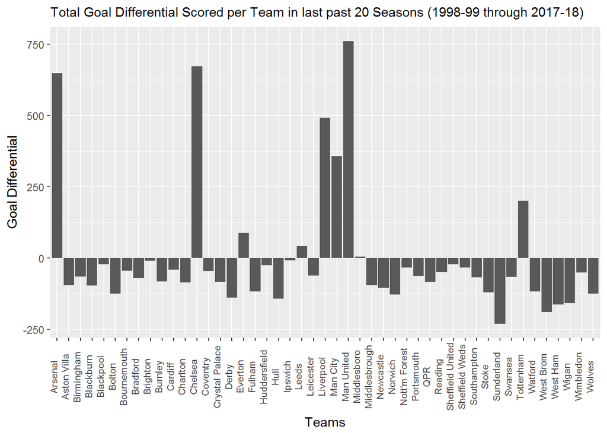

### Mean Goals Scored

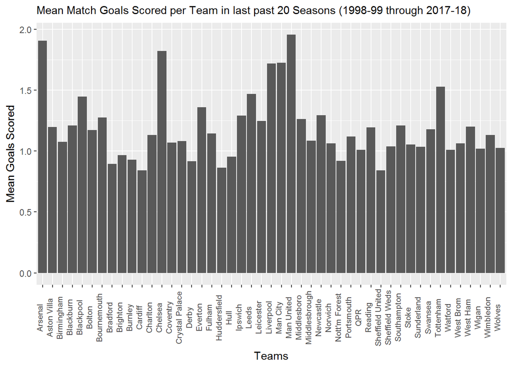

### Mean Goals Conceded

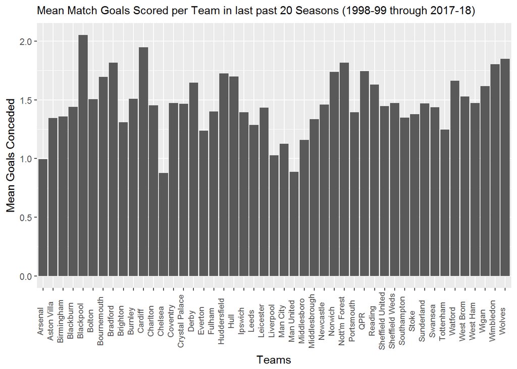

## Markov Chain Simulation

### Southampton vs. Arsenal

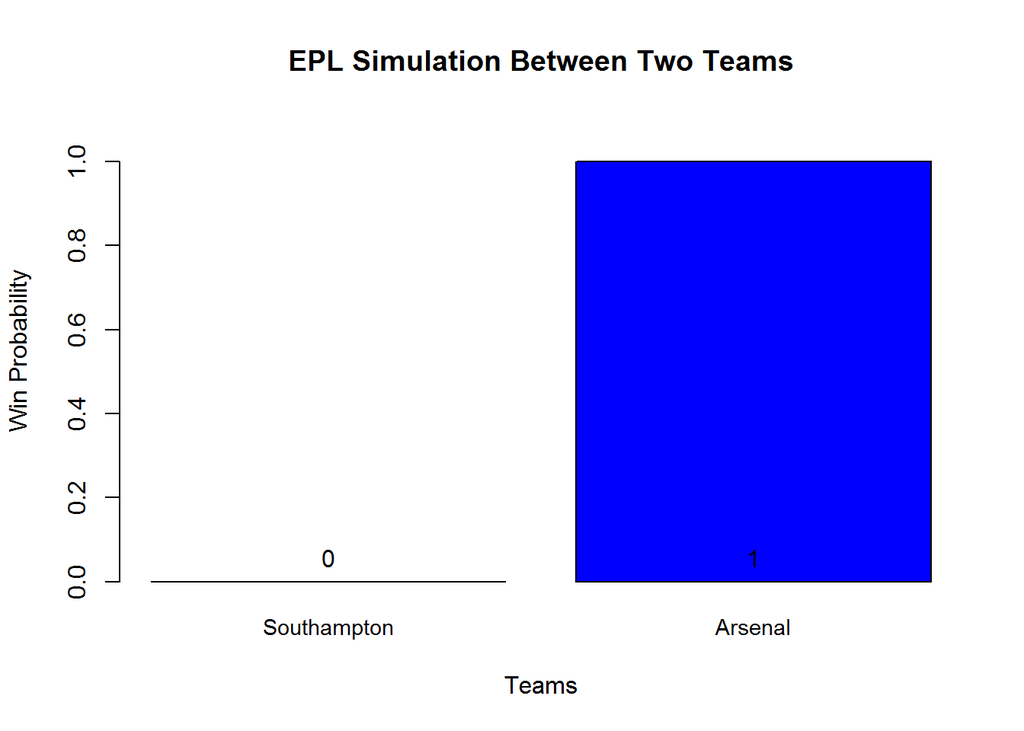

```r
# Bar plot
yMax = max(matchOutcome)+.1

barPlotTitle = "EPL Simulation Between Two Teams"

bp = barplot(matchOutcome, ylim = c(0.0, yMax), col="blue", main=barPlotTitle,ylab ="Win Probability", xlab ="Teams",
             names.arg=c(matchTeams), cex.names=0.9,)
text(bp, 0, round(matchOutcome, 2),cex=1,pos=3)
```

### What We Did and Why

We decided to take our efforts back to a memorable place and simulate EPL data. Based on data we pulled from http://www.football-data.co.uk/englandm.php, we gathered and cleaned EPL data from 1998-2018. The object was to project a potential season winner using historical data. The potential winner is represented using probabilites of position placement. The Poisson distribution was a logical method based on the randomness caused by the rpois function.

### What We Found

The Markov Chain Simulation between Southampton and Arsenal resulted in 100% chance of Arsenal winning, given a sample size of 100 and 10 simulations.

### Why It Matters

This would be a helpful tool with gambling if we were to bring in betting odds and manage to indentify trends through simulations. Overall this was an exciting opportunity for us to see how simulations work in real world settings. Sports analytics is a growing industry as analytics as a whole evolves.

Statistical Note: For this example, independent Poisson distributions with means ExpHG and ExpAG have been used to simulate results from.

For each iteration, the remaining season results are simulated, a total points and Goal difference table is created. We calculate ranks based on points and goal differential.